# Część 2: Model zbudowany na cechach zadania i ucznia

# Krótki opis modelu

Żeby ograniczyć rozmiar danych, zdecydowaliśmy się na wybranie co czwartej szkoły z każdego kraju. Ponieważ najmniejsza liczba szkół w kraju to 44 (Luksemburg), takie podejście powinno dać wystarczająco dużo informacji żeby poprawnie odwzorować strukturę danych. Zachowanie struktury potwierdzają stosunki liczb rozwiązań zadań w populacji i próbce, które we wszystkich przypadkach są bardzo bliskie 4. Zbadaliśmy również zachowanie struktury krajów, gdzie dostaliśmy równie dobre wyniki. Procedura otrzymania zbioru danych została opisana pod koniec raportu, w sekcjach 7 i 8.

Zauważyliśmy że mniej gęste wypróbkowanie nie zachowuje struktury szkół w niektórych krajach, na przykład w Luksemburgu. Jest to spowodowane wysoką wariancją liczb uczniów w szkołach i małą liczbą szkół w tych krajach.

Zbadaliśmy dwie transformacje czasu rozwiązań: transformację Boxa-Coxa oraz transformację Log-Trans. Transformacje dały stosunkowo podobne wyniki. Po analizie normalności reszt w modelach zbudowanych w oparciu o obie tansformacje wybraliśmy transformację Log-Trans.

Diagnostyka modelu przebiegła pomyślnie. Reszty w modelu są skupione wokół jednej wartości, brak obserwacji odstających. Rozkład reszt standardyzowanych jest symetryczny, choć nie jest normalny ze względu na zbyt wysoką kurtozę. Wariancja reszt jest stosunkowo jednorodna. Wobec tego przyjmujemy że nasz model jest poprawny.

# 1. Streszczenie wyników analizy

Nasz model zbudowaliśmy w oparciu o następujące zmienne, wybrane za pomocą kryterium BIC:

- “BOOKID”, numer kwestionariusza
- “task”, numer zadania
- “CNT”, kraj
- “gender”, płeć ucznia
- “WEALTH”, wskaźnik zamożności rodziny (zmienna numeryczna)
- “HEDRES”, wskaźnik zasobów edukacyjnych w domu (zmienna numeryczna)
- “MISCED”, wykształcenie matki (klasyfikacja ISCED)
- “FISCED”, wykształcenie ojca (klasyfikacja ISCED)
- “IMMIG”, status imigranta
  - “-1”: Brak odpowiedzi
  - “1”: Natywny
  - “2”: Pierwsze pokolenie
  - “3”: Drugie pokolenie
- “ST012Q09NA”, liczba instrumentów muzycznych w domu
  - “-1”: Brak odpowiedzi
  - “1”: Brak
  - “2”: Jeden
  - “3”: Dwa
  - “4”: Trzy lub więcej
- “ST013Q01TA”, liczba książek w domu
  - “-1”: Brak odpowiedzi
  - “1”: 0-10
  - “2”: 11-25
  - “3”: 26-100
  - “4”: 101-200
  - “5”: 201-500
  - “6”: Ponad 500
- “ST123Q04NA”, “moi rodzice zachęcają mnie do bycia pewnym siebie”
  - “-1”: Brak odpowiedzi
  - “1”: Bardzo się nie zgadzam
  - “2”: Nie zgadzam się
  - “3”: Zgadzam się
  - “4”: Bardzo się zgadzam
- “ST119Q04NA”, “uważam się za osobę ambitną”
  - “-1”: Brak odpowiedzi
  - “1”: Bardzo się nie zgadzam
  - “2”: Nie zgadzam się
  - “3”: Zgadzam się
  - “4”: Bardzo się zgadzam
- “ST062Q03TA”, jak często uczeń spóźniał się do szkoły w przeciągu ostatnich dwóch tygodni
  - “-1”: Brak odpowiedzi
  - “1”: W ogóle
  - “2”: Raz lub dwa razy
  - “3”: Trzy lub cztery razy
  - “4”: Pięć razy lub więcej.

Spośród wybranych zmiennych największe znaczenie dla wyjaśnienia zmienności czasu rozwiązywania miały zasoby edukacyjne w domu, numer zadania oraz płeć. Niestety, wyjaśniają one zmienność jedynie w niewielkim stopniu. Ponadto wyestymowane współczynniki dla tych zmiennych są bardzo niewielkie.

W szczegółowej analizie zmiennych skupiliśmy się na kraju, płci oraz wykształceniu rodziców. Ta ostatnia zmienna miała szczególnie interesującą zależność. Najlepszy czas rozwiązywania zadań osiągnęli uczniowie, którzy nie udzielili odpowiedzi na wykształcenie dowolnego rodzica (co sugeruje brak co najmniej jednego rodzica). W porównaniu z wykształceniem podstawowym, lepsze wykształcenie matki również miało pozytywny wpływ na czas rozwiązywania zadań. Zaskakujące okazało się to, że wykształcenie ojca wydłużało czas rozwiązywania zadań, tym bardziej im lepiej wykształcony był ojciec.

Różnice pomiędzy płciami były nieznaczne w porównaniu ze zmiennością populacyjną.

Po uwzględnieniu róznic w poziomie zamożności rodzin, spodziewamy się że za różnice pomiędzy krajami będą odpowiadać przede wszystkim róznice w systemie edukacji. Spośród 55 badanych krajów, 34 mają lepsze czasy rozwiązywania niż Polska. Kraje o podobnych czasach rozwiązywania (tzn. braku zauważalnych statystycznie różnic w teście LSD) to głównie kraje środkowo lub “brzegowo”-europejskie, takie jak Grecja, Łotwa, Słowacja, oraz kraje egzotyczne, takie jak Kostaryka, Chile. Wyjątkiem od tej reguły jest Belgia oraz Szwecja.

Wyniki analizy zilustrowaliśmy graficznie za pomocą odpowiednich wykresów w sekcji 6 (“wizualizacja”).

# 2. Struktura danych i wybór podpopulacji

Ponieważ wyjściowe dane zawierały obserwacje nietypowe, stworzyliśmy na ich podstawie własny zestaw danych. Szczegółowy opis procedury otrzymania zestawu danych znajduje się w sekcji 7.

```r
# fread jest o wiele szybsze niż inne funkcje, więc warto zapisać dane po obrobieniu i ładować z pliku przy następnych analizach
pelne.dane <- fread("Curated_full_data.csv", sep=",", header=TRUE, stringsAsFactors = TRUE)
```

```
##
Read 0.0% of 3594594 rows
Read 17.2% of 3594594 rows
Read 33.9% of 3594594 rows
Read 50.6% of 3594594 rows
Read 66.8% of 3594594 rows
Read 83.7% of 3594594 rows
Read 3594594 rows and 28 (of 28) columns from 0.583 GB file in 00:00:10
```

```r
head(pelne.dane)
```

```
##    CNTSTUID BOOKID item_short           S     time position task   Q Q.nb
## 1:  3600001     44    M496Q02 Full credit 1.323750        3 M496 Q02    2
## 2:  3600001     44    M423Q01 Full credit 0.242650        3 M423 Q01    1
## 3:  3600001     44    M603Q01 Full credit 1.475100        3 M603 Q01    1
## 4:  3600001     44    M571Q01 Full credit 1.740217        3 M571 Q01    1
## 5:  3600001     44    M564Q01 Full credit 1.008767        3 M564 Q01    1
## 6:  3600001     44    M564Q02 Full credit 1.878183        3 M564 Q02    2
##    CNT CNTSCHID gender WEALTH CULTPOSS HEDRES ANXTEST MISCED FISCED IMMIG
## 1: AUS  3600428      2 2.6171  -0.2107 1.1563 -0.5306      4      6     1
## 2: AUS  3600428      2 2.6171  -0.2107 1.1563 -0.5306      4      6     1
## 3: AUS  3600428      2 2.6171  -0.2107 1.1563 -0.5306      4      6     1
## 4: AUS  3600428      2 2.6171  -0.2107 1.1563 -0.5306      4      6     1
## 5: AUS  3600428      2 2.6171  -0.2107 1.1563 -0.5306      4      6     1
## 6: AUS  3600428      2 2.6171  -0.2107 1.1563 -0.5306      4      6     1
##    AGE ST012Q09NA ST013Q01TA LANGTEST_QQQ ST012Q06NA ST123Q04NA ST011Q02TA
## 1:  16          4          5          313          4          4          1
## 2:  16          4          5          313          4          4          1
## 3:  16          4          5          313          4          4          1
## 4:  16          4          5          313          4          4          1
## 5:  16          4          5          313          4          4          1
## 6:  16          4          5          313          4          4          1
##    ST119Q04NA ST062Q03TA
## 1:          3          1
## 2:          3          1
## 3:          3          1
## 4:          3          1
## 5:          3          1
## 6:          3          1
```

Żeby ograniczyć rozmiar danych, z każdego kraju została losowo wybrana jedna czwarta szkół. Porcedura wyboru szkół została szczegółowo opisana w sekcji 8.

Ładowanie listy wybranych szkół:

```r
wybrane.szkoly <- fread("Chosen_schools.csv", sep=",", header=TRUE, stringsAsFactors = TRUE)
wybrane.szkoly <- factor(unlist(wybrane.szkoly))
```

Wybieramy próbkę na podstawie wybranych szkół

```r
probka <- pelne.dane[pelne.dane$CNTSCHID %in% wybrane.szkoly, ]
probka$CNTSCHID = factor(probka$CNTSCHID, levels=unique(probka$CNTSCHID))
probka$CNTSTUID = factor(probka$CNTSTUID, levels=unique(probka$CNTSTUID))
probka$BOOKID = factor(probka$BOOKID)
head(probka)
```

```
##    CNTSTUID BOOKID item_short           S     time position task   Q Q.nb
## 1:  3600003     51    M559Q01 Full credit 3.312083        1 M559 Q01    1
## 2:  3600003     51    M800Q01 Full credit 2.914683        1 M800 Q01    1
## 3:  3600003     51    M998Q04 Full credit 1.236750        2 M998 Q04    2
## 4:  3600003     51    M447Q01   No credit 0.913600        1 M447 Q01    1
## 5:  3600003     51    M273Q01   No credit 2.947633        1 M273 Q01    1
## 6:  3600003     51    M408Q01   No credit 1.874683        1 M408 Q01    1
##    CNT CNTSCHID gender WEALTH CULTPOSS HEDRES ANXTEST MISCED FISCED IMMIG
## 1: AUS  3600369      2 0.3214  -1.2278 0.0321  0.4415      4      4     1
## 2: AUS  3600369      2 0.3214  -1.2278 0.0321  0.4415      4      4     1
## 3: AUS  3600369      2 0.3214  -1.2278 0.0321  0.4415      4      4     1
## 4: AUS  3600369      2 0.3214  -1.2278 0.0321  0.4415      4      4     1
## 5: AUS  3600369      2 0.3214  -1.2278 0.0321  0.4415      4      4     1
## 6: AUS  3600369      2 0.3214  -1.2278 0.0321  0.4415      4      4     1
##      AGE ST012Q09NA ST013Q01TA LANGTEST_QQQ ST012Q06NA ST123Q04NA
## 1: 15.42          2          2          313          3          4
## 2: 15.42          2          2          313          3          4
## 3: 15.42          2          2          313          3          4
## 4: 15.42          2          2          313          3          4
## 5: 15.42          2          2          313          3          4
## 6: 15.42          2          2          313          3          4
##    ST011Q02TA ST119Q04NA ST062Q03TA
## 1:          1          3          2
## 2:          1          3          2
## 3:          1          3          2
## 4:          1          3          2
## 5:          1          3          2
## 6:          1          3          2
```

Usuwamy pełne dane żeby oszczędzić miejsce w pamięci.

```r
rm(pelne.dane)
gc()
```

```
##            used  (Mb) gc trigger   (Mb)  max used   (Mb)
## Ncells  2000194 106.9    3205452  171.2   2326587  124.3
## Vcells 17940645 136.9  179817544 1371.9 224499353 1712.8
```

# 3. Transformacja danych

W pierwszym kroku ustalamy referencyjne poziomy zmiennych kategorycznych.

```r
probka$CNT <- relevel(probka$CNT, ref="POL")
probka$MISCED <- relevel(probka$MISCED, ref="0")
probka$FISCED <- relevel(probka$FISCED, ref="0")
probka$IMMIG <- relevel(probka$IMMIG, ref="1")
probka$ST012Q09NA <- relevel(probka$ST012Q09NA, ref="1")
probka$ST013Q01TA <- relevel(probka$ST013Q01TA, ref="1")
probka$ST012Q06NA <- relevel(probka$ST012Q06NA, ref="1")
probka$ST123Q04NA <- relevel(probka$ST123Q04NA, ref="1")
probka$ST011Q02TA <- relevel(probka$ST011Q02TA, ref="1")
probka$ST119Q04NA <- relevel(probka$ST119Q04NA, ref="1")
probka$ST062Q03TA <- relevel(probka$ST062Q03TA, ref="1")
```

Rozpatrujemy transformację czasu żeby otrzymać rozkład zbliżony do normalnego.

```r
# Brakuje pamieci na uwzględnienie szkoly oraz na zagnieżdżenie języka testu w kraju.
bc.model <- aov(time ~ BOOKID + task + CNT + gender + WEALTH + CULTPOSS + HEDRES +  MISCED + FISCED + IMMIG + AGE + ST012Q09NA + ST013Q01TA + LANGTEST_QQQ + ST012Q06NA + ST123Q04NA + ST011Q02TA + ST119Q04NA + ST062Q03TA, data=probka)
summary(bc.model)
```

```
##                  Df  Sum Sq Mean Sq  F value   Pr(>F)
## BOOKID           35   19770   564.9  360.132  < 2e-16 ***
## task             44  113541  2580.5 1645.185  < 2e-16 ***
## CNT              54   25256   467.7  298.180  < 2e-16 ***
## gender            1     904   904.2  576.456  < 2e-16 ***
## WEALTH            1     518   517.9  330.161  < 2e-16 ***
## CULTPOSS          1    1711  1711.5 1091.136  < 2e-16 ***
## HEDRES            1    1056  1055.7  673.029  < 2e-16 ***
## MISCED            7     502    71.6   45.678  < 2e-16 ***
## FISCED            7     229    32.6   20.812  < 2e-16 ***
## IMMIG             3     454   151.2   96.402  < 2e-16 ***
## AGE               1      38    37.6   23.981 9.73e-07 ***
## ST012Q09NA        4     287    71.8   45.798  < 2e-16 ***
## ST013Q01TA        6    1729   288.2  183.738  < 2e-16 ***
## LANGTEST_QQQ     22     940    42.7   27.230  < 2e-16 ***
## ST012Q06NA        4     311    77.8   49.603  < 2e-16 ***
## ST123Q04NA        4     421   105.2   67.059  < 2e-16 ***
## ST011Q02TA        2      27    13.5    8.609 0.000183 ***
## ST119Q04NA        4     335    83.9   53.464  < 2e-16 ***
## ST062Q03TA        4     826   206.5  131.637  < 2e-16 ***
## Residuals    895368 1404391     1.6
## ---
## Signif. codes:  0 '***' 0.001 '**' 0.01 '*' 0.05 '.' 0.1 ' ' 1
```

W pierwszej kolejności aby zmniejszyć model usuniemy niektóre zmienne o bardzo niskiej wartości statystyki F: `ST011Q02TA`, `LANGTEST_QQQ`, `AGE` oraz `ST012Q06NA`. Dalsze kroki wyboru modelu przeprowadzimy po znalezieniu optymalnej transformacji czasu.

```r
bc.model <- aov(time ~ BOOKID + task + CNT + gender + WEALTH + CULTPOSS + HEDRES +  MISCED + FISCED + IMMIG + ST012Q09NA + ST013Q01TA + ST123Q04NA + ST119Q04NA + ST062Q03TA, data=probka)
gc()
```

```
##             used   (Mb) gc trigger   (Mb)  max used   (Mb)
## Ncells   2911616  155.5    4703850  251.3   2954977  157.9
## Vcells 192853175 1471.4  607063059 4631.6 758583685 5787.6
```

```r
summary(bc.model)
```

```
##                 Df  Sum Sq Mean Sq F value Pr(>F)
## BOOKID          35   19770   564.9  359.82 <2e-16 ***
## task            44  113541  2580.5 1643.77 <2e-16 ***
## CNT             54   25256   467.7  297.92 <2e-16 ***
## gender           1     904   904.2  575.96 <2e-16 ***
## WEALTH           1     518   517.9  329.88 <2e-16 ***
## CULTPOSS         1    1711  1711.5 1090.19 <2e-16 ***
## HEDRES           1    1056  1055.7  672.45 <2e-16 ***
## MISCED           7     502    71.6   45.64 <2e-16 ***
## FISCED           7     229    32.6   20.79 <2e-16 ***
## IMMIG            3     454   151.2   96.32 <2e-16 ***
## ST012Q09NA       4     288    72.1   45.91 <2e-16 ***
## ST013Q01TA       6    1730   288.4  183.70 <2e-16 ***
## ST123Q04NA       4     428   107.0   68.17 <2e-16 ***
## ST119Q04NA       4     366    91.5   58.28 <2e-16 ***
## ST062Q03TA       4     842   210.6  134.16 <2e-16 ***
## Residuals   895397 1405650     1.6
## ---
## Signif. codes:  0 '***' 0.001 '**' 0.01 '*' 0.05 '.' 0.1 ' ' 1
```

Znajdziemy wykładnik transformacji Boxa-Coxa dla wybranej próbki.

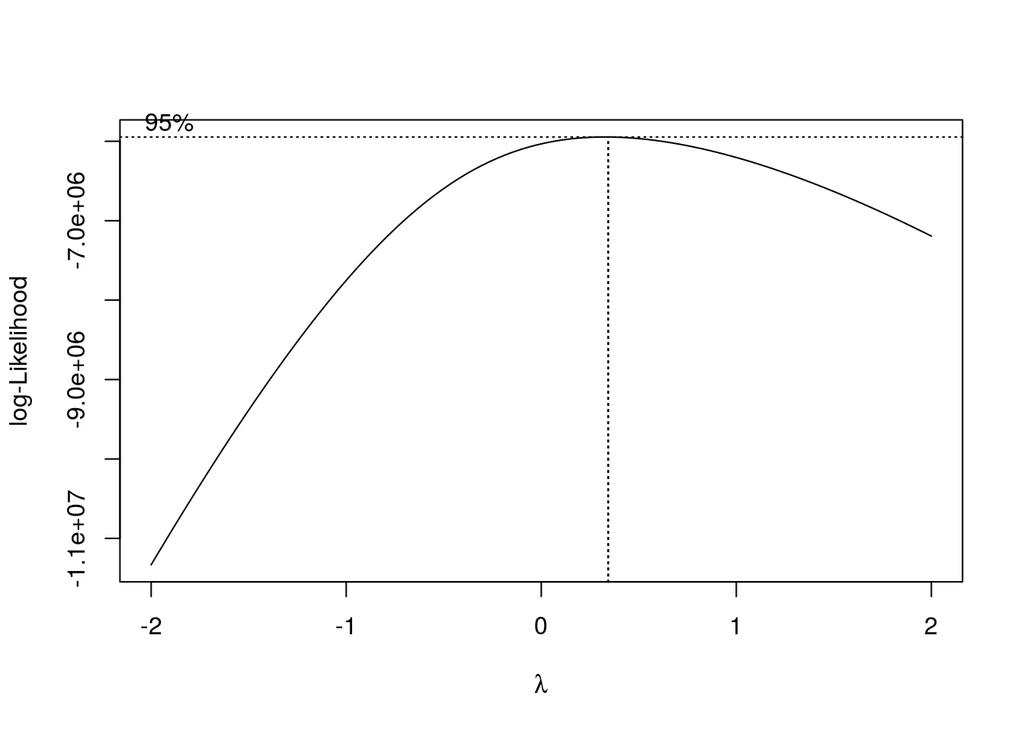

```r
bc <- boxcox(bc.model, plotit=TRUE)
```

```r
wykladnik <- bc$x[which.max(bc$y)]
```

Optymalny wykładnik wynosi 0.3434343. Log-wiarygodność wynosi -5.945982810^{6}.

Porównajmy transformację Boxa-Coxa z transformacją log-trans.

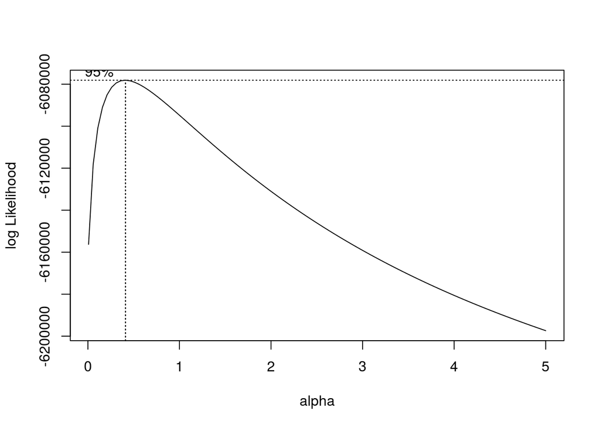

```r
ltr <- logtrans(bc.model, plotit=TRUE, alpha=seq(-min(probka$time) + 0.01, 0.5*max(probka$time), length.out=100))
```

```r
przesuniecie <- ltr$x[which.max(ltr$y)]
```

Optymalne przesunięcie wynosi 0.4108118. Log-wiarygodność wynosi -6.078106110^{6}.

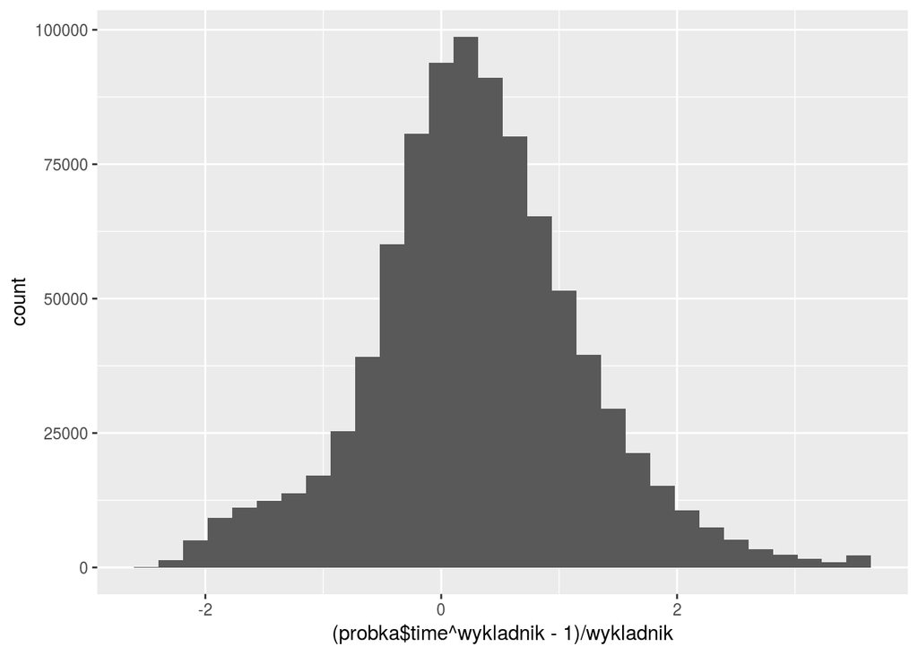

```r
qplot((probka$time^wykladnik-1)/wykladnik)
```

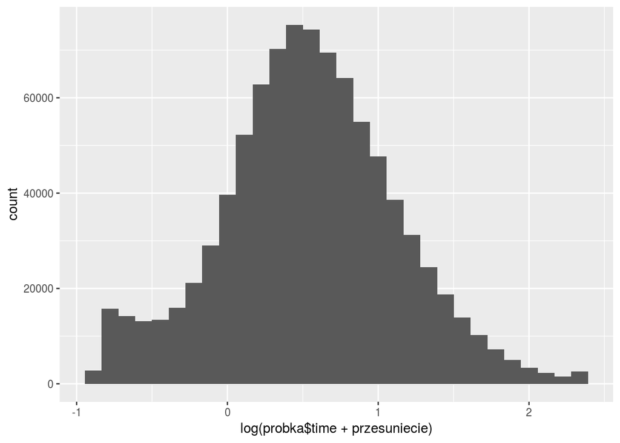

```r
qplot(log(probka$time + przesuniecie))
```

Transformacje dały bardzo podobne rezultaty. Odpowiednią transformację wybierzemy poprzez diagnostykę reszt obu modeli.

Transformujemy czas przy użyciu obu transformacji i usuwamy model użyty do znalezienia transformacji.

```r
probka$time.bc <- (probka$time^wykladnik - 1)/wykladnik
probka$time.log <- log(probka$time + przesuniecie)
rm(bc.model, bc, ltr)
```

Przeprowadzamy diagnostykę reszt w obu transformacjach pod kątem normalności i jednorodności wariancji.

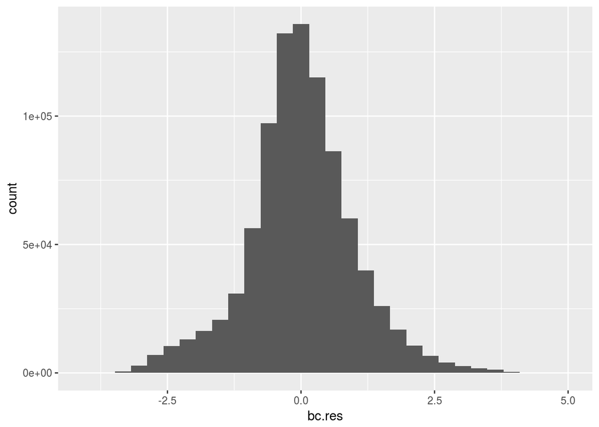

```r
bc.model <- lm(time.bc ~ BOOKID + task + CNT + gender + WEALTH + CULTPOSS + HEDRES +  MISCED + FISCED + IMMIG + ST012Q09NA + ST013Q01TA + ST123Q04NA + ST119Q04NA + ST062Q03TA, data=probka)
bc.res <- rstandard(bc.model)
qplot(bc.res)
```

```r
cvm.test(bc.res)
```

```
##
##  Cramer-von Mises normality test
##
## data:  bc.res
## W = 730.07, p-value = 7.37e-10
```

```r
rm(bc.model, bc.res)
gc()
```

```
##            used  (Mb) gc trigger   (Mb)  max used   (Mb)
## Ncells  2092127 111.8    4703850  251.3   4703850  251.3
## Vcells 20090595 153.3  559581954 4269.3 873516436 6664.5
```

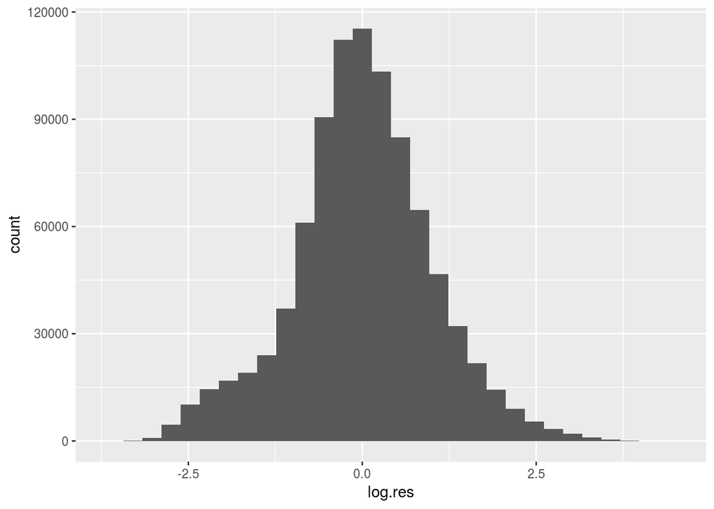

```r
log.model <- lm(time.log ~ BOOKID + task + CNT + gender + WEALTH + CULTPOSS + HEDRES +  MISCED + FISCED + IMMIG + ST012Q09NA + ST013Q01TA + ST123Q04NA + ST119Q04NA + ST062Q03TA, data=probka)
log.res <- rstandard(log.model)
qplot(log.res)
```

```r
cvm.test(log.res)
```

```
##
##  Cramer-von Mises normality test
##
## data:  log.res
## W = 345.49, p-value = 7.37e-10
```

```r
rm(log.model, log.res)
gc()
```

```
##            used  (Mb) gc trigger   (Mb)  max used   (Mb)
## Ncells  2092222 111.8    4703850  251.3   4703850  251.3
## Vcells 20091298 153.3  447665563 3415.5 873516436 6664.5
```

Wartość statystyki W w teście Cramera-von Misesa, mierzącej odległość dystrybuanty empirycznej od teoretycznej, jest dwukrotnie mniejsza dla transformacji logarytmicznej. Z tego powodu wybieramy tę transformację do stworzenia właściwego modelu.

Usuwamy zbędne kolumny żeby ograniczyć zużycie pamięci.

```r
probka <- probka[, -c('time.bc')]
gc()
```

```
##            used  (Mb) gc trigger   (Mb)  max used   (Mb)
## Ncells  2075281 110.9    4703850  251.3   4703850  251.3
## Vcells 19159564 146.2  358132450 2732.4 873516436 6664.5
```

# 4. Wybór modelu

```r
# eval=FALSE bo model został zapisany poniżej a wybór modelu bardzo długo trwa
bic.model <- lm(time.log ~ BOOKID + task + CNT + gender + WEALTH + CULTPOSS + HEDRES +  MISCED + FISCED + IMMIG + ST012Q09NA + ST013Q01TA + ST123Q04NA + ST119Q04NA + ST062Q03TA, data=probka)
anova(bic.model)
```

Wybierzemy model metodą krokową poprzez usuwanie kolejnych zmiennych.

```r
chosen.model <- step(bic.model, .~., k=log(nrow(probka)), direction="backward")
```

```r
chosen.model$call
```

Zapisujemy otrzymaną formułę do dalszych analiz.

```r
chosen.formula <- time.log ~ BOOKID + task + CNT + gender + WEALTH +
    HEDRES + MISCED + FISCED + IMMIG + ST012Q09NA + ST013Q01TA +
    ST123Q04NA + ST119Q04NA + ST062Q03TA
```

Usuwamy wybrany model, który został stworzony na wybranych danych z próbki.

```r
rm(bic.model, chosen.model)
gc()
```

Budujemy model na pełnej próbie na podstawie wybranej formuły.

```r
chosen.model <- lm(chosen.formula, data=probka)
chosen.anova <- anova(chosen.model)
chosen.aov <- aov(chosen.formula, data=probka)
chosen.anova
```

```
## Analysis of Variance Table
##
## Response: time.log
##                Df Sum Sq Mean Sq  F value    Pr(>F)
## BOOKID         35   4487  128.19  430.313 < 2.2e-16 ***
## task           44  22529  512.02 1718.734 < 2.2e-16 ***
## CNT            54   6033  111.72  375.031 < 2.2e-16 ***
## gender          1    369  368.56 1237.178 < 2.2e-16 ***
## WEALTH          1     62   62.08  208.384 < 2.2e-16 ***
## HEDRES          1    641  641.31 2152.725 < 2.2e-16 ***
## MISCED          7    175   25.03   84.027 < 2.2e-16 ***
## FISCED          7     86   12.30   41.275 < 2.2e-16 ***
## IMMIG           3    181   60.47  202.967 < 2.2e-16 ***
## ST012Q09NA      4    154   38.57  129.484 < 2.2e-16 ***
## ST013Q01TA      6    581   96.78  324.878 < 2.2e-16 ***
## ST123Q04NA      4    152   37.88  127.163 < 2.2e-16 ***
## ST119Q04NA      4    146   36.40  122.187 < 2.2e-16 ***
## ST062Q03TA      4    420  105.05  352.613 < 2.2e-16 ***
## Residuals  895398 266745    0.30
## ---
## Signif. codes:  0 '***' 0.001 '**' 0.01 '*' 0.05 '.' 0.1 ' ' 1
```

# 5. Diagnostyka

Przed wizualizacją sprawdźmy poprawność modelu.

### Jenorodność wariancji:

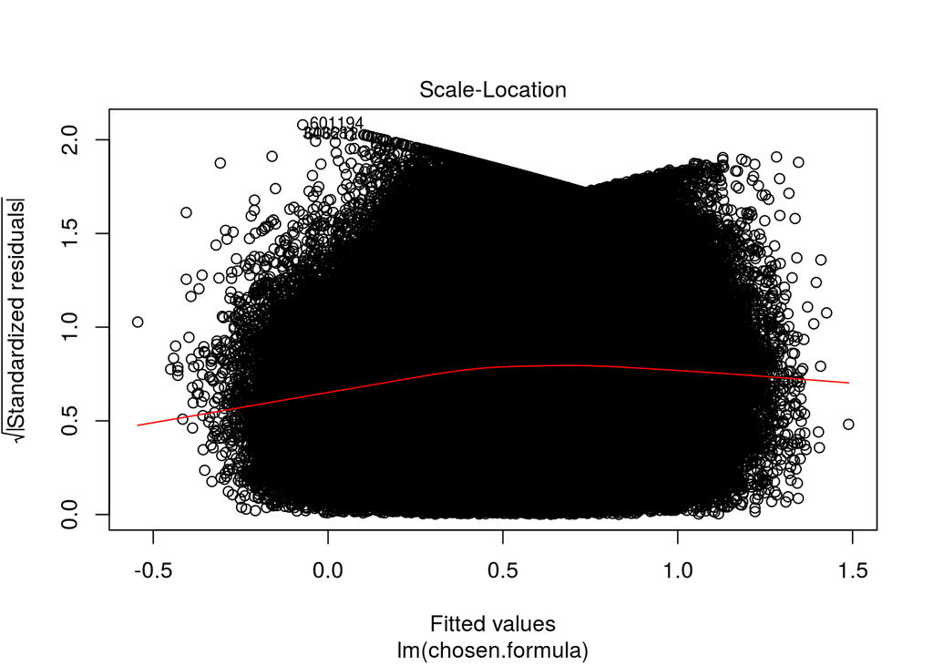

```r
plot(chosen.model, which=3)
```

Wariancja jest stosunkowo jednorodna, odchylenia są nieznaczne. Zastosujemy test Flignera-Killeena, który jest odporny na odchylenia od normalności:

```r
fligner.test(chosen.anova)
```

```
##
##  Fligner-Killeen test of homogeneity of variances
##
## data:  chosen.anova
## Fligner-Killeen:med chi-squared = 33.416, df = 4, p-value =
## 9.815e-07
```

P-wartość jest niska, ale z powodu liczności próby możemy nie odrzucać hipotezy o jednorodności wariancji.

### Normalność reszt:

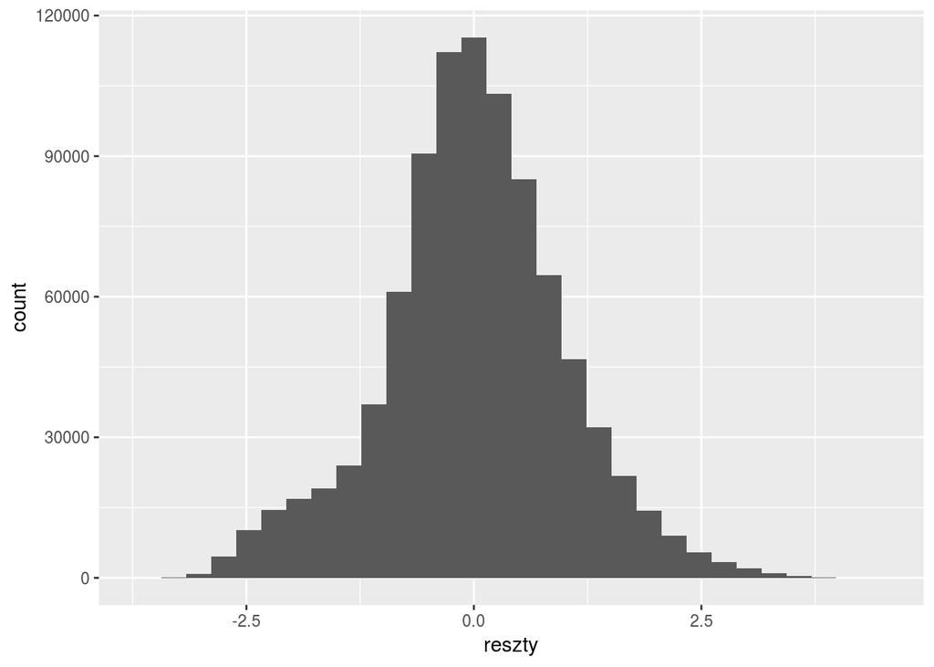

```r
reszty <- rstandard(chosen.model)
qplot(reszty)
```

```r
cvm.test(reszty)
```

```
##
##  Cramer-von Mises normality test
##
## data:  reszty
## W = 345.49, p-value = 7.37e-10
```

```r
ks.test(reszty, pnorm)
```

```
##
##  One-sample Kolmogorov-Smirnov test
##
## data:  reszty
## D = 0.036217, p-value < 2.2e-16
## alternative hypothesis: two-sided
```

Reszty są zbliżone do rozkładu normalnego, ale mają zbyt dużą kurtozę równą 0.4923791 (w porównaniu do `0` dla rozkładu normalnego), przez co testy odrzucają hipotezę o normalności. Reszty są rozłożone dość symetrycznie, współczynnik skośności wynosi -0.0435539.

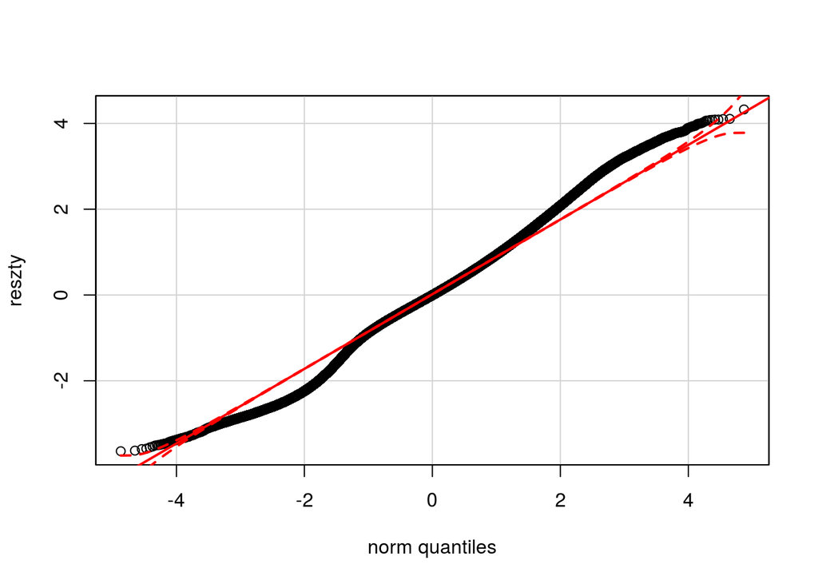

```r
qqPlot(reszty)
```

Widać że kurtoza jest głównym powodem nienormalności rozkładu reszt, możemy zatem uznać że model jest poprawny.

### Obserwacje wpływowe:

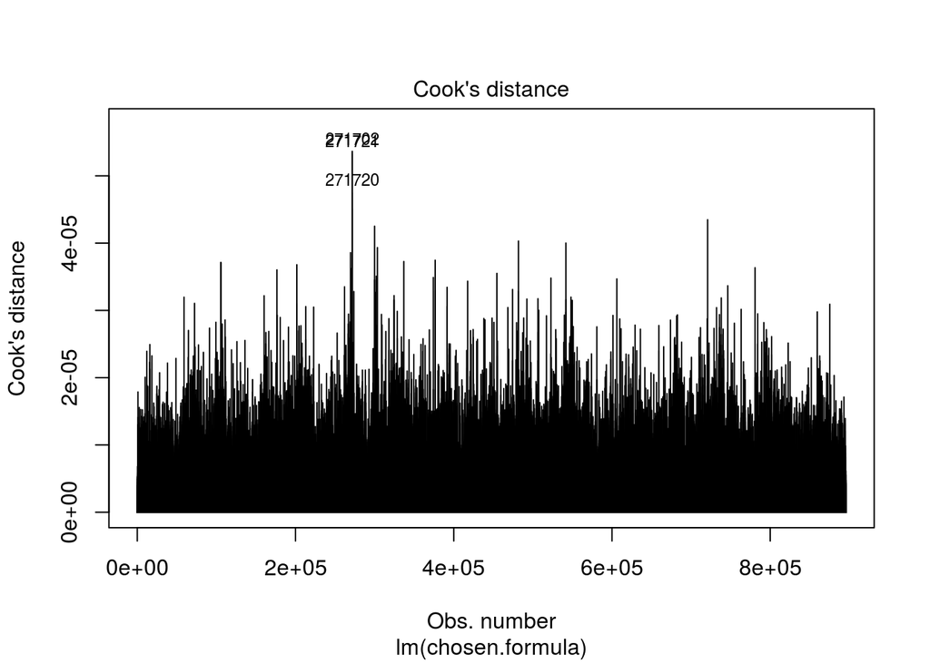

```r
plot(chosen.model, which=4)
```

Odległość Cooka jest bardzo niewielka we wszystkich przypadkach.

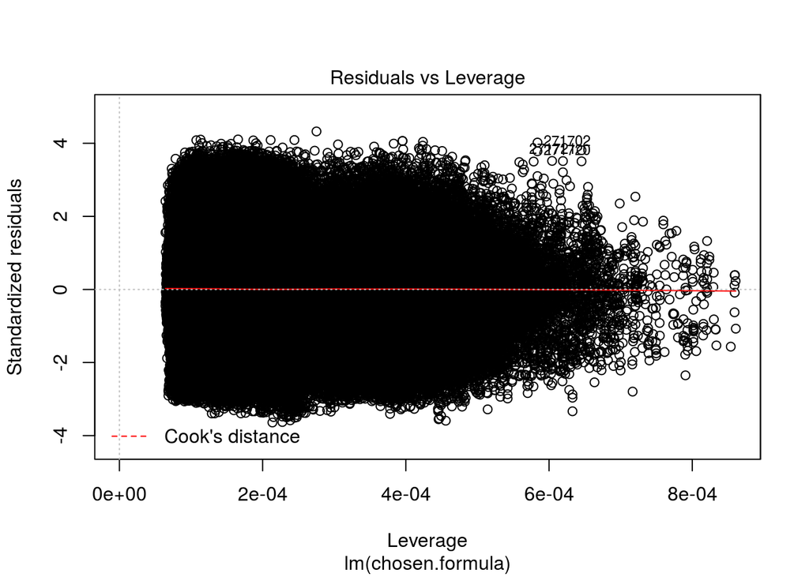

```r
plot(chosen.model, which=5)
```

Reszty są skupione, brak obserwacji odstających.

Z powyższej diagnostyki możemy wnioskować że model jest poprawny. Zbyt wysoka kurtoza reszt oraz lekko niejednorodna wariancja w grupach nie powinny znacznie wpływać na estymację modelu. Możemy przejść do wizualizacji modelu.

# 6. Wizualizacja

Istotność poszczególnych zmiennych pokazuje następujący wykres wartości statystyki F:

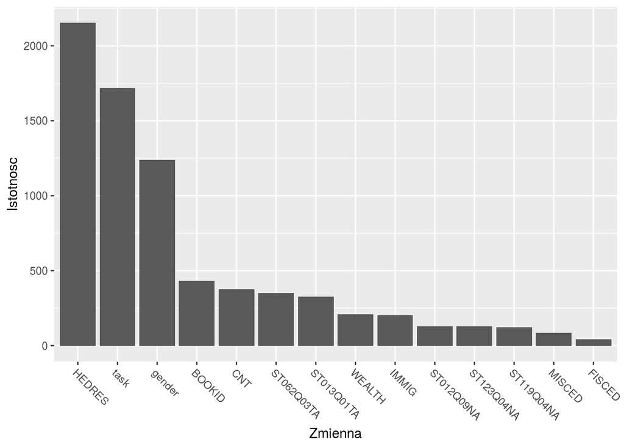

```r
coef.names <- names(chosen.model$coefficients)
F.data <- data.frame("Zmienna" = names(chosen.model$model)[-1], "Istotnosc" = chosen.anova$`F value`[-length(chosen.anova$`F value`)])
F.data$Zmienna <- factor(F.data$Zmienna, levels=F.data$Zmienna[order(F.data$Istotnosc, decreasing=T)])
ggplot(F.data, aes(x=Zmienna, y=Istotnosc)) + geom_bar(stat='Identity') +  theme(axis.text.x = element_text(angle = -45, hjust = 0))
```

Najwięcej zmienności w czasie rozwiązywania zadań wyjaśnia wskaźnik zasobów edukacyjnych w domu. Wykształcenie rodziców, zmienne odnoszące się do osobowości ucznia oraz liczba instrumentów muzycznych w domu wyjaśniają mało zmienności.

### Zależność czasu rozwiązywania od zasobów edukacyjnych

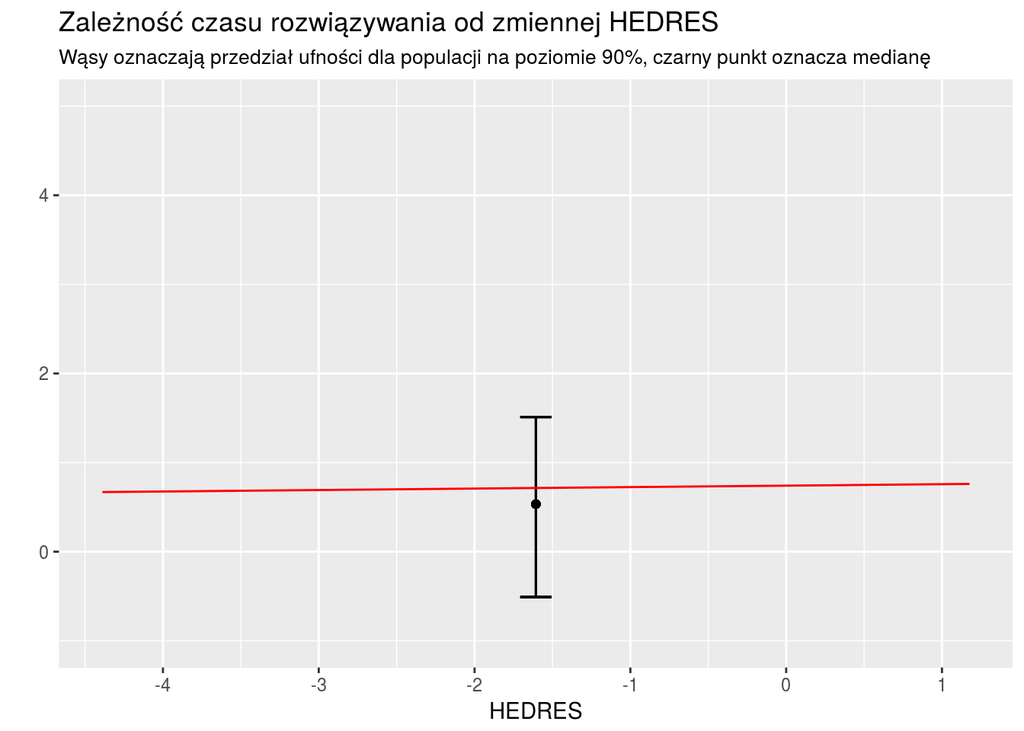

```r
hedres.xlim <- c(min(probka$HEDRES), max(probka$HEDRES))
hedres.plot.data <- data.frame('x' = seq(hedres.xlim[1], hedres.xlim[2], length.out=10))
hedres.plot.data$hedres.estim <- chosen.model$coefficients[1] + chosen.model$coefficients["HEDRES"]*hedres.plot.data$x
ggplot(data=hedres.plot.data) + geom_errorbar(aes(x=mean(hedres.xlim), ymin=quantile(probka$time.log, 0.05), ymax=quantile(probka$time.log, 0.95)), width=0.2) + geom_line(aes(x=x, y=hedres.estim), col=I("red")) + xlim(hedres.xlim) + xlab("HEDRES") + ylim(c(-1, 5)) + ylab("") + geom_point(aes(x=mean(hedres.xlim), y=quantile(probka$time.log, 0.5))) + ggtitle("Zależność czasu rozwiązywania od zmiennej HEDRES", subtitle="Wąsy oznaczają przedział ufności dla populacji na poziomie 90%, czarny punkt oznacza medianę")
```

Zależność jest widoczna, ale w porównaniu ze zmiennością czasu rozwiązywania w populacji nie jest bardzo duża. To sugeruje że nasze zmienne dość słabo objaśniają czas rozwiązywania.

### Zależność czasu rozwiązywania od wykształcenia rodziców

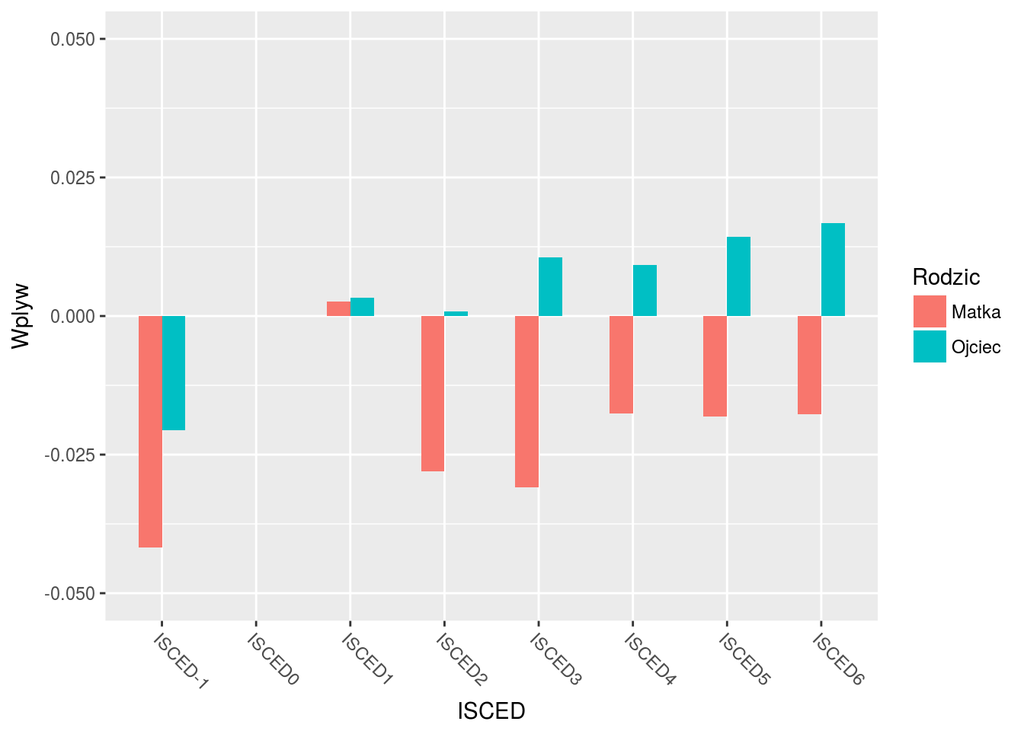

```r
edu.data <- data.frame("ID" = c("MISCED0", "FISCED0", coef.names[grep("ISCED", coef.names)]), "Wplyw"=c(0, 0, chosen.model$coefficients[grep("ISCED", coef.names)]))
edu.data$ISCED <- factor(str_sub(edu.data$ID, start=2), levels=c("ISCED-1", "ISCED0", "ISCED1", "ISCED2", "ISCED3", "ISCED4", "ISCED5", "ISCED6"))
edu.data$Rodzic <- ifelse(is.na(str_match(edu.data$ID, "^M")), "Ojciec", "Matka")
ggplot(edu.data, aes(x=ISCED, y=Wplyw, fill=Rodzic)) + geom_bar(stat="identity", position="dodge", width=0.5) + theme(axis.text.x = element_text(angle = -45, hjust = 0)) + ylim(c(-0.05, 0.05))
```

Widać, ze o ile wykształcenie matki korzystnie wpływa na czas rozwiązywania zadań, to wykształcenie ojca wręcz przeciwnie. Ponadto uczniowie którzy nie podali informacji o co najmniej jednym rodzicu rozwiązują zadania dużo szybciej niż inni.

### Zależność czasu rozwiązywania od kraju:

Po uwzględnieniu zmiennych takich jak zasoby edukacyjne lub zamożność, które nie są zbalansowane w krajach, dużą rolę powinien odgrywać system edukacji.

```r
kraj.czas <- data.frame("Kraj"=c("CNTPOL", names(chosen.model$coefficients[grep("CNT", names(chosen.model$coefficients))])), "Roznica" = c(0, chosen.model$coefficients[grep("CNT", names(chosen.model$coefficients))] ))
kraj.czas$Kraj <- str_replace(kraj.czas$Kraj, "CNT", "")
malMap <- joinCountryData2Map(kraj.czas, joinCode = "ISO3",
  nameJoinColumn = "Kraj")
```

```
## 52 codes from your data successfully matched countries in the map
## 3 codes from your data failed to match with a country code in the map
## 191 codes from the map weren't represented in your data
```

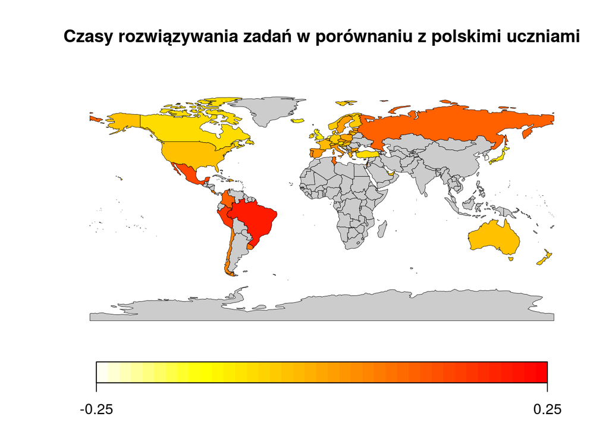

```r
mapCountryData(malMap, nameColumnToPlot="Roznica", catMethod = seq(-0.25, 0.25, length.out=40),
  missingCountryCol = gray(.8), mapTitle="Czasy rozwiązywania zadań w porównaniu z polskimi uczniami", lwd=0.4, borderCol="black")
```

Widać pewną korelację przestrzenną. Najlepiej wypadły: Korea, Hong Kong, Holandia i Katar. Najgorzej wypadły Brazylia, Peru, Meksyk i Rosja. Spośród 55 badanych krajów, 34 mają lepsze czasy rozwiązywania niż Polska.

Porównajmy pary krajów żeby wyodrębnić grupy. Ze względu na duży rozmiar próby, rozszerzymy przedziały ufności. Uzyskamy dzięki temu ciekawszą strukturę zależności. Dobierzemy p-wartość tak, aby Polska znalazla się w 3 grupach.

```r
# Grupowanie krajow
lsd <- LSD.test(chosen.aov, "CNT", alpha=0.02, p.adj="holm")
grupy.krajow <- lsd$groups
grupy.pl <- grupy.krajow[grupy.krajow$trt=="POL",]
wszystkie.grupy <- unique(unlist(str_split(grupy.krajow$M, '')))
grupy.krajow2 <- lapply(wszystkie.grupy, function(g) as.character(grupy.krajow$trt[grep(g, grupy.krajow$M)]))
names(grupy.krajow2) <- wszystkie.grupy
grupy.pl2 <- grupy.krajow2[which(!is.na(str_match(grupy.pl$M, wszystkie.grupy)))]
skroty <- sapply(unique(unlist(grupy.pl2)), isoToName)
kraje.legenda <- paste(names(skroty), skroty, sep=', ')
```

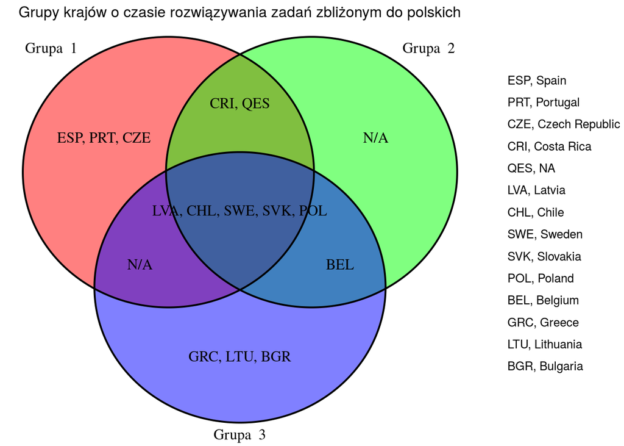

```r
# Rysowanie diagramu
vd <- venn.diagram(grupy.pl2, NULL, fill=rainbow(length(grupy.pl2)), main="Grupy krajów o czasie rozwiązywania zadań zbliżonym do polskich", main.fontfamily = "sans", cex=1, euler.d=F, scaled=F)
lg <- legendGrob(labels=kraje.legenda, gp=gpar(cex=0.8), vgap=unit(0.4, 'lines'))
overlaps <- calculate.overlap(grupy.pl2)
overlaps <- overlaps[order(as.integer(str_replace(names(overlaps), 'a', '')))]
for (i in 1:length(overlaps)){
  if(length(overlaps[[i]])>0)   vd[[i+3+length(grupy.pl2)]]$label <- paste(overlaps[[i]], collapse = ", ")  else  vd[[i+3+length(grupy.pl2)]]$label <- "N/A"
}
for (i in (length(overlaps)+1):(length(overlaps)+length(grupy.pl2))){
  vd[[i+3+length(grupy.pl2)]]$label <- paste("Grupa ", i-length(overlaps))
}
# for(i in 1:length(vd)) vd[[i]]$label <- i
vd.g <- gTree(children = gList(vd))
grid.newpage()
grid.arrange(vd.g, lg, ncol=2, widths=c(4, 1.2))
```

### Zależność od płci:

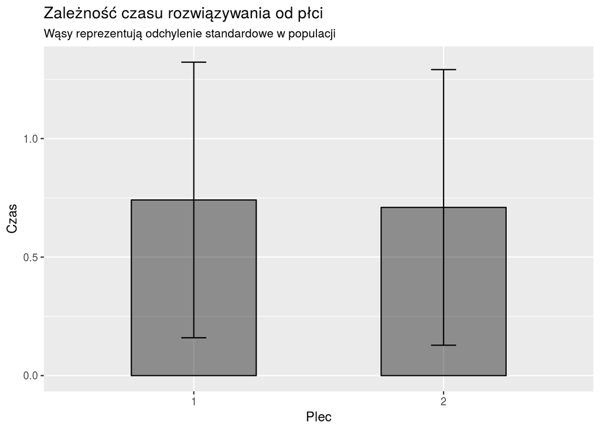

```r
plec.czas <- data.frame("Plec" = factor(c(1, 2)), "Czas" = chosen.model$coefficients["(Intercept)"] + c(0, chosen.model$coefficients["gender2"]))
ggplot(data=plec.czas, aes(x=Plec, y=Czas)) + geom_bar(stat="identity", width=0.5, alpha=I(0.4), fill="black", col="black") + geom_errorbar(aes(ymin=Czas - sd(probka$time.log), ymax=Czas + sd(probka$time.log)), width=0.1) + ggtitle("Zależność czasu rozwiązywania od płci", subtitle="Wąsy reprezentują odchylenie standardowe w populacji")
```

Różnice pomiędzy płciami są dość nieznaczne, choć zauważalne statystycznie.

```r
pairwise.t.test(probka$time, probka$gender)
```

```
##
##  Pairwise comparisons using t tests with pooled SD
##
## data:  probka$time and probka$gender
##
##   1
## 2 <2e-16
##
## P value adjustment method: holm
```

Nieznaczną różnicę widać również na boxplotach utworzonych bezpośrednio z czasów rozwiązywania (bez użycia modelu).

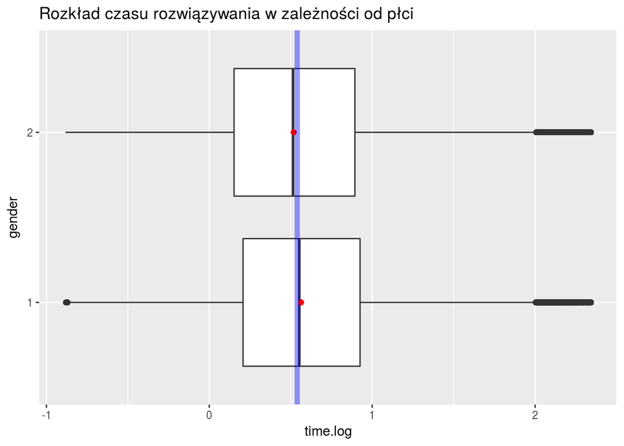

```r
ggplot(probka, aes(y = time.log, x = gender))   + geom_boxplot() + stat_summary(fun.y = mean, shape = 16, color = 'red', size = 2, geom = 'point') + geom_hline(aes(yintercept = mean(probka$time.log)), color = "blue", size = 2, alpha=0.4) + coord_flip() + ggtitle("Rozkład czasu rozwiązywania w zależności od płci")
```

# 7. Obróbka danych

```r
# Żeby nie kompilować, dajemy eval=FALSE
knitr::opts_chunk$set(echo = TRUE, warnings=FALSE, message = FALSE, eval=FALSE)
```

Ładowanie i obróbka danych

```r
studenci <- read.spss("Cy6_ms_cmb_stu_qqq.sav", use.value.labels=FALSE, to.data.frame = TRUE)
kraje <- studenci[, c("CNTRYID", "CNT")]
kraje <- unique(kraje)  # Mapowanie numer - skrót ISO3
studenci <- studenci[, c("CNT",
                         "CNTSCHID",
                         "CNTSTUID",
                         "ST004D01T",
                         "WEALTH",
                         "CULTPOSS",
                         "HEDRES",
                         "ANXTEST",
                         "MISCED",
                         "FISCED",
                         "IMMIG",
                         "AGE",
                         "PA002Q07NA",
                         "PA002Q08NA",
                         "PA002Q10NA",
                         "PA003Q02TA",
                         "IC013Q12NA",
                         "IC014Q08NA",
                         "ST012Q09NA",
                         "ST013Q01TA",
                         "LANGTEST_QQQ",
                         "ST012Q06NA",
                         "ST123Q04NA",
                         "ST011Q02TA",
                         "ST119Q04NA",
                         "ST034Q01TA",
                         "ST034Q02TA",
                         "ST039Q03NA",
                         "ST039Q05NA",
                         "ST039Q04NA",
                         "ST062Q03TA",
                         "ST076Q06NA",
                         "ST078Q06NA",
                         "ST076Q10NA",
                         "ST078Q10NA",
                         "IC003Q01TA",
                         "IC008Q01TA",
                         "IC008Q02TA")]  # BOOKID jest w zadaniach
names(studenci)[names(studenci)=='ST004D01T'] = "gender"

load("actionTimeScoreMath.rda")
zadania <- actionTimeScoreMath; rm(actionTimeScoreMath)
zadania <- zadania[, c("CNTSTUID", "BOOKID", "item_short", "S", "T", "position")]
names(zadania)[names(zadania) == "T"] = "time"
zadania <- zadania[!is.na(zadania$time), ]
zadania$task <- gsub("Q\\d+", "", zadania$item_short)
zadania$task <- as.factor(zadania$task)
zadania$Q <- gsub("M\\d+\\D?Q", "Q", zadania$item_short)
zadania$Q <- as.factor(zadania$Q)
# Przenumerowanie Q
non.empty <- apply(table(zadania$task, zadania$Q), 1, function(x) ifelse(x==0, 0, 1))
question.id <- apply(non.empty, 2, function(x) ifelse(x==0, 0, cumsum(x)))
zadania$Q.nb <- apply(zadania, 1, function(x) question.id[x["Q"], x["task"]])
zadania$Q.nb <- factor(zadania$Q.nb)
rm(non.empty, question.id)
```

Podgląd danych

```r
head(zadania)
head(studenci)
```

```r
table(zadania$task, zadania$Q)
table(zadania$task, zadania$Q.nb)
```

Łączenie tabel zadań i studentów

```r
indeksy.uczniow <- match(zadania$CNTSTUID, studenci$CNTSTUID)
pelne.dane <- cbind(zadania, studenci[indeksy.uczniow, -3])
rm(zadania, studenci, indeksy.uczniow)
gc()
head(pelne.dane)
```

Liczby rozwiązań zadań z kwestionariuszy:

```r
table(pelne.dane$BOOKID)
qplot(log10(c(table(pelne.dane$BOOKID))))
```

Widać, że kwestionariusze występują w bardzo różnych ilościach. Są trzy wyraźne grupy liczności - kwestionariusze mają po kilkadziesiąt, kilka tysięcy lub kilkanaście tysięcy rozwiązań.

Sprawdźmy czy kwestionariusze są równo rozłożone w krajach.

```r
table(pelne.dane$CNT, pelne.dane$BOOKID)
```

```r
samotne.kwestionariusze <- which(apply(table(pelne.dane$CNT, pelne.dane$BOOKID), 2, function(x) sum(x!=0))==1)
samotne.kwestionariusze <- names(samotne.kwestionariusze)
do.usuniecia <- which(!is.na(match(pelne.dane$BOOKID, samotne.kwestionariusze)))
pelne.dane <- pelne.dane[-do.usuniecia, ]
rm(do.usuniecia)
pelne.dane$BOOKID <- factor(pelne.dane$BOOKID)
gc()
```

Struktura kwestionariuszy po obróbce:

```r
table(pelne.dane$CNT, pelne.dane$BOOKID)
qplot(log10(c(table(pelne.dane$BOOKID))))
```

Brak specyficznych kwestionariuszy (mających mniej niż 100 rozwiazań).

W niektórych krajach brakuje rozwiązań. Z tego powodu przefaktorujemy kraje, przy okazji usuwając dziwne tabulacje za skrótem kraju.

```r
pelne.dane$CNT <- str_trim(as.character(pelne.dane$CNT))
pelne.dane$CNT <- factor(pelne.dane$CNT)
```

Przyjrzyjmy się teraz liczbom rozwiązań oraz uczniów w krajach.

```r
table(pelne.dane$CNT)
tapply(pelne.dane$CNTSTUID, pelne.dane$CNT, function(x) length(unique(x)))
```

Kraje oznaczone QUC i QUE wyraźnie odstają pod względem liczby rozwiązań oraz uczniów od innych krajów.

```r
szkoly <- unique(pelne.dane[, c("CNT", "CNTSCHID")])
liczby.szkol <- tapply(szkoly$CNTSCHID, szkoly$CNT, length)
sort(liczby.szkol)[1:10]
```

QUC oraz QUE mają tylko jedną szkołę objętą programem. Skrót QUC oznacza Massachussets, a skrót QUE oznacza Północną Karolinę. Ponieważ nie są to kraje tylko stany USA, i nie znamy powodu wyodrębnienia tych stanów, usuwamy je z danych.

```r
quc.que <- which(!is.na(match(pelne.dane$CNT, c("QUE", "QUC"))))
if(length(quc.que)>0) pelne.dane <- pelne.dane[-quc.que, ]  # w przypadku length(quc.que) = 0 to by spowodowało usunięcie danych
pelne.dane$CNT <- factor(pelne.dane$CNT)
```

Sprawdźmy czy język kwestionariusza odpowiada krajowi.

```r
table(pelne.dane$CNT, pelne.dane$LANGTEST_QQQ)
```

```r
apply(table(pelne.dane$CNT, pelne.dane$LANGTEST_QQQ), 1, function(x) sum(x!=0))
```

W niektórych krajach kwestionariusze były rozwiązywane w różnych językach (w Hiszpanii m.in. hiszpański, baskijski, galicyjski). Język kwestionariusza moze mieć duży wpływ na czas rozwiązywania, więc warto go uwzględnić jako efekt zagnieżdżony w kraju.

Sprawdźmy proporcje pustych pól w poszczególnych kolumnach:

```r
tmp <- nrow(pelne.dane)
empty.fields <- apply(pelne.dane, 2, function(x) sum(is.na(x))/tmp)
empty.fields
```

Część kolumn jest prawie pusta. Wybierzmy te, które mają co najwyżej 5% brakujących odpowiedzi. Dodajmy wykształcenie ojca, wynik testu i wskaźnik zasobów kulturowych w domu, ponieważ te zmienne są interesujące, a brakujące pola mogą być uzupełnione dodatkowym poziomem faktora.

```r
chosen.columns <- empty.fields <= 0.05
chosen.columns['FISCED'] = TRUE
chosen.columns['CULTPOSS']= TRUE
chosen.columns['S'] = TRUE
pelne.dane <- pelne.dane[, chosen.columns]
rm(empty.fields, tmp)
gc()
head(pelne.dane)
```

W przypadku zmiennych numerycznych musimy usunąć brakujące dane.

```r
missing.data <- is.na(pelne.dane$HEDRES) | is.na(pelne.dane$CULTPOSS) | is.na(pelne.dane$ANXTEST) | is.na(pelne.dane$WEALTH)
pelne.dane <- pelne.dane[!missing.data, ]
rm(missing.data)
head(pelne.dane)
```

Przefaktorowujemy dane po obróbce.

```r
pelne.dane$S <- factor(pelne.dane$S)
pelne.dane$CNT <- factor(pelne.dane$CNT)
pelne.dane$item_short <- factor(pelne.dane$item_short)
pelne.dane$CNTSCHID <- factor(pelne.dane$CNTSCHID)
pelne.dane$CNTSTUID <- factor(pelne.dane$CNTSTUID)
pelne.dane$gender <- factor(pelne.dane$gender)
pelne.dane$BOOKID <- factor(pelne.dane$BOOKID)
pelne.dane$position <- factor(pelne.dane$position)
pelne.dane$task <- factor(pelne.dane$task)
pelne.dane$Q <- factor(pelne.dane$Q)
pelne.dane$Q.nb <- factor(pelne.dane$Q.nb)
pelne.dane$MISCED <- factor(pelne.dane$MISCED)
pelne.dane$FISCED <- factor(pelne.dane$FISCED)
pelne.dane$IMMIG <- factor(pelne.dane$IMMIG)
pelne.dane$ST012Q09NA <- factor(pelne.dane$ST012Q09NA)
pelne.dane$ST013Q01TA <- factor(pelne.dane$ST013Q01TA)
pelne.dane$LANGTEST_QQQ <- factor(pelne.dane$LANGTEST_QQQ)
pelne.dane$ST012Q06NA <- factor(pelne.dane$ST012Q06NA)
pelne.dane$ST123Q04NA <- factor(pelne.dane$ST123Q04NA)
pelne.dane$ST011Q02TA <- factor(pelne.dane$ST011Q02TA)
pelne.dane$ST119Q04NA <- factor(pelne.dane$ST119Q04NA)
pelne.dane$ST062Q03TA <- factor(pelne.dane$ST062Q03TA)
```

Dodajemy dodatkowe poziomy faktorów dla zakodowania brakujących obserwacji

```r
levels(pelne.dane$S) <- c(levels(pelne.dane$S), -1)
levels(pelne.dane$CNT) <- c(levels(pelne.dane$CNT), -1)
levels(pelne.dane$item_short) <- c(levels(pelne.dane$item_short), -1)
levels(pelne.dane$CNTSCHID) <- c(levels(pelne.dane$CNTSCHID), -1)
levels(pelne.dane$CNTSTUID) <- c(levels(pelne.dane$CNTSTUID), -1)
levels(pelne.dane$gender) <- c(levels(pelne.dane$gender), -1)
levels(pelne.dane$BOOKID) <- c(levels(pelne.dane$BOOKID), -1)
levels(pelne.dane$position) <- c(levels(pelne.dane$position), -1)
levels(pelne.dane$task) <- c(levels(pelne.dane$task), -1)
levels(pelne.dane$Q) <- c(levels(pelne.dane$Q), -1)
levels(pelne.dane$Q.nb) <- c(levels(pelne.dane$Q.nb), -1)
levels(pelne.dane$MISCED) <- c(levels(pelne.dane$MISCED), -1)
levels(pelne.dane$FISCED) <- c(levels(pelne.dane$FISCED), -1)
levels(pelne.dane$IMMIG) <- c(levels(pelne.dane$IMMIG), -1)
levels(pelne.dane$ST012Q09NA) <- c(levels(pelne.dane$ST012Q09NA), -1)
levels(pelne.dane$ST013Q01TA) <- c(levels(pelne.dane$ST013Q01TA), -1)
levels(pelne.dane$LANGTEST_QQQ) <- c(levels(pelne.dane$LANGTEST_QQQ), -1)
levels(pelne.dane$ST012Q06NA) <- c(levels(pelne.dane$ST012Q06NA), -1)
levels(pelne.dane$ST123Q04NA) <- c(levels(pelne.dane$ST123Q04NA), -1)
levels(pelne.dane$ST011Q02TA) <- c(levels(pelne.dane$ST011Q02TA), -1)
levels(pelne.dane$ST119Q04NA) <- c(levels(pelne.dane$ST119Q04NA), -1)
levels(pelne.dane$ST062Q03TA) <- c(levels(pelne.dane$ST062Q03TA), -1)
```

Oznaczamy brakujące dane w faktorach.

```r
pelne.dane$S[is.na(pelne.dane$S)] <- -1
pelne.dane$FISCED[is.na(pelne.dane$FISCED)] <- -1
pelne.dane$MISCED[is.na(pelne.dane$MISCED)] <- -1
pelne.dane$IMMIG[is.na(pelne.dane$IMMIG)] <- -1
pelne.dane$ST012Q09NA[is.na(pelne.dane$ST012Q09NA)] <- -1
pelne.dane$ST013Q01TA[is.na(pelne.dane$ST013Q01TA)] <- -1
pelne.dane$LANGTEST_QQQ[is.na(pelne.dane$LANGTEST_QQQ)] <- -1
pelne.dane$ST012Q06NA[is.na(pelne.dane$ST012Q06NA)] <- -1
pelne.dane$ST123Q04NA[is.na(pelne.dane$ST123Q04NA)] <- -1
pelne.dane$ST011Q02TA[is.na(pelne.dane$ST011Q02TA)] <- -1
pelne.dane$ST119Q04NA[is.na(pelne.dane$ST119Q04NA)] <- -1
pelne.dane$ST062Q03TA[is.na(pelne.dane$ST062Q03TA)] <- -1
```

Ustalamy referencyjne poziomy faktorów.

```r
pelne.dane$CNT <- relevel(pelne.dane$CNT, ref=which(levels(pelne.dane$CNT)=="POL"))
```

Czas rozwiązania jest mierzony w milisekundach. Dla ułatwienia interpretacji zakodujemy go w minutach.

```r
pelne.dane$time <- pelne.dane$time/60000
```

Sprawdźmy kwantyle czasu rozwiązań na obecność obserwacji odstających:

```r
quantile(pelne.dane$time)
qplot(seq(0, 1, length.out=101), quantile(pelne.dane$time, probs=seq(0, 1, length.out=101)))
qplot(seq(0, 1, length.out=101), log10(quantile(pelne.dane$time, probs=seq(0, 1, length.out=101))))
```

Widać wyraźny skok o rząd wielkości po prawej stronie odpowiadający za obserwacje odstające (uczeń odszedł od komputera). Kwantyl rzędu 0.99 wynosi 6.748645, a najwyższy czas rozwiązywania wynosi 10 i jest 1.4817789 razy większy od 99% rozwiązań. Z tego powodu będziemy cenzurować czasy rozwiązania dłuższe niż 10 minut.

```r
pelne.dane$time <- pmin(pelne.dane$time, 10)
```

Rozkład czasu rozwiązań:

```r
qplot(pelne.dane$time)
```

Widać małą górkę po prawej stronie odpowiadającą trymowanym czasom rozwiązywania.

Zapisujemy obrobione dane do przyszłego załadowania.

```r
# write.csv(pelne.dane, "Curated_full_data.csv", row.names=FALSE)
```

# 8. Wybór szkół do analizy

Wybieramy z każdego kraju co czwartą szkołę (tzw. proportionate quota sampling). Wybieranie ustaloniej liczby gorzej odwzorowuje strukturę zadań i może zaburzyć wariancję wewnątrz krajów.

```r
# wybrane.szkoly <- tapply(szkoly$CNTSCHID, szkoly$CNT, function(x) sample(x, as.integer(length(x)/4), replace=F))
# wybrane.szkoly <- lapply(wybrane.szkoly, as.character)  # konwersja do str bo inaczej unlist zmienia faktory na liczby
# wybrane.szkoly <- unlist(wybrane.szkoly)
# wybrane.szkoly <- factor(wybrane.szkoly)
```

Zapisujemy wybrane szkoły w pliku żeby mieć stały dataset do wszystkich analiz.

```r
# write.csv(wybrane.szkoly, "Chosen_schools.csv", row.names=FALSE)
```

Wybór próbki na podstawie wybranych szkół:

```r
probka <- pelne.dane[pelne.dane$CNTSCHID %in% wybrane.szkoly, ]
head(probka)
tapply(probka$CNTSCHID, probka$CNT, function(x) length(unique(x)))
# Przepoziomowanie faktorów
probka$CNTSCHID = factor(probka$CNTSCHID, levels=unique(probka$CNTSCHID))
probka$CNTSTUID = factor(probka$CNTSTUID, levels=unique(probka$CNTSTUID))
probka$BOOKID = factor(probka$BOOKID)
```

Porównanie struktury zadań w próbce i populacji

```r
table(pelne.dane$item_short); table(probka$item_short)
table(pelne.dane$item_short)/table(probka$item_short)
table(pelne.dane$CNT); table(probka$CNT)
table(pelne.dane$CNT)/table(probka$CNT)
qplot(c(table(pelne.dane$item_short)/table(probka$item_short)), geom="histogram", xlab="Proporcja liczby obserwacji w populacji do liczby obserwacji w próbce dla różnych podpunktów")
qplot(c(table(pelne.dane$CNT)/table(probka$CNT)), geom="histogram", xlab="Proporcja liczby obserwacji w populacji do liczby obserwacji w próbce dla różnych krajów")
```

Przy wyborze co czwartej szkoły struktura zadań i krajów jest dość dobrze zachowana.

W przypadku mniejszej liczby szkół zauważyliśmy że zdarza się kilka nietypowych proporcji obserwacji w krajach. W najbardziej nietypowych krajach liczba rozwiązań w próbie była dwukrotnie mniejsza od spodziewanej. To sugeruje nierównomierny rozkład uczniów w szkołach. Być może uwzględnienie rozmiaru szkół pozwoliłoby na dalsze zmniejszenie liczby danych przy zachowaniu struktury.

W przypadku wybierania co dziesiątej szkoły Luksemburg był przykładem kraju o zaburzonej strukturze, a Francja o zachowanej. Z tego powodu interesujące jest porównanie struktury szkół w tych krajach.

```r
# Konwersja do faktorów po wybraniu kraju przyspiesza obliczenia ponieważ usuwa zbędne poziomy
qplot(c(tapply(factor(pelne.dane[pelne.dane$CNT=="LUX", ]$CNTSTUID), factor(pelne.dane[pelne.dane$CNT=="LUX", ]$CNTSCHID), function(x) length(unique(x)))), main="Struktura szkół w Luksemburgu")
qplot(c(tapply(factor(pelne.dane[pelne.dane$CNT=="FRA", ]$CNTSTUID), factor(pelne.dane[pelne.dane$CNT=="FRA", ]$CNTSCHID), function(x) length(unique(x)))), main="Struktura szkół we Francji")
```

Widać że struktura jest bardzo różna. We Francji większość szkół ma około 10 uczniów. W Luksemburgu szkoły sa dużo bardziej zróżnicowane, liczba uczniów wynosi od kilku do 125. Ponadto liczba szkół w Luksemburgu wynosi 44, podczas gdy średnia liczba szkół dla innych krajów wynosi 261. Tak wysoka wariancja w połączeniu z niewielką próbą była najprawdopodbniej przyczyną braku zachowania struktury szkół. Wybieranie co czwatej szkoły zapewniło wystarczająco gęste wypróbkowanie żeby zachować wariancję szkół w Luksemburgu:

```r
# Konwersja do faktorów po wybraniu kraju przyspiesza obliczenia ponieważ usuwa zbędne poziomy
qplot(c(tapply(factor(probka[probka$CNT=="LUX", ]$CNTSTUID), factor(probka[probka$CNT=="LUX", ]$CNTSCHID), function(x) length(unique(x)))), main="Struktura szkół w Luksemburgu w próbce")
qplot(c(tapply(factor(probka[probka$CNT=="FRA", ]$CNTSTUID), factor(probka[probka$CNT=="FRA", ]$CNTSCHID), function(x) length(unique(x)))), main="Struktura szkół we Francji w próbce")
```

```r
# Inny sposób wybrania próbki, uwzględniający strukturę zadań, ale nie uczniów w szkołach:
# rozmiary.podgrup <- tapply(1:nrow(pelne.dane), list(pelne.dane$CNT, pelne.dane$item_short), function(x) length(x))
# rozmiary.podgrup <- c(rozmiary.podgrup)
# rozmiary.podgrup <- ifelse(is.na(rozmiary.podgrup), 0, rozmiary.podgrup)
# qplot(rozmiary.podgrup, geom="histogram", binwidth=10, xlab="Rozmiary grup")
# indeksy.probki <- tapply(1:nrow(pelne.dane), list(pelne.dane$CNT, pelne.dane$item_short), function(x) sample(x,  as.integer(length(x)/10), replace=F))
# indeksy.probki <- sort(unlist(indeksy.probki))
# probka <- pelne.dane[indeksy.probki, ]
```